[figure not shown]

# Data Analysis

### Andrey Shestakov (avshestakov@hse.ru)

## Decision trees<sup>1</sup>

<sup>1. Some materials are taken from machine learning course of Victor Kitov</sup>

# Let's recall previous lecture

- Metric methods: Nearest Centroid, K Nearest Neighbours
  - Work both for classification and regression
  - Lazy learning - simply remember training dataset
  - No parameters - only hyper-parameters
- Cluster hypothesis - the core of metric methods
- Similarity measures and distances: euclidean, cosine, edit-distance, Jaccard similarity, etc...
- Feature scaling is important!
- Various modifications:
  - weighted domain
  - work on "tied" cases
  - adaptive K
  - ...
- Get ready to face with
  - Curse of dimentionality
  - Slow prediction speed

# Decision trees

# Intuition

## Intuition 1

- A perfumery company developed a new unisex smell
- To find their key segments it they run open world testing
- Each respondent leaves
  - responce if she likes it or not (`+1`|`-1`)
  - some info about her
    - Gender
    - Age
    - Education
    - Current career
    - Have domestic animals
    - etc..

## Intuition 1

In the end the description of the segments could look like this

- `[Gender = F][Age > 21][Age <= 25][Education = Higher][Have domestic animals = No]` - like in 82% of cases
- `[Gender = M][Age > 25][Age <= 30][Current Career = Manager]` - don't like in 75% of cases
- ...

## Intuition 2

- You are going to take a loan god, please, no to buy something expensive, and provide your application form
- Bank employee is checking it accoring to some rules like:
  1. Current bank account > 200k rubles. - go to step 2, otherwise 3
  2. Duration < 30 months - go to step 4, otherwise REJECT
  3. Current employment > 1 year - ACCEPT, otherwise REJECT
  4. ...

## Intuition 2

[figure not shown]

## Intuition 3

[figure not shown]

## Intuition 4

[figure not shown]

## Intuition 4

[figure not shown]

## Definition of decision tree

- Prediction is performed by tree $T$ (directed, connected, acyclic graph)
- Node types
  1. A root node, $root(T)$
  2. Internal nodes $int(T)$, each having $\ge2$ child nodes
  3. Terminal nodes (leafs), $terminal(T)$, which do not have child nodes but have associated prediction values

## Definition of decision tree

- for each non-terminal node $t$ a **check-function** $Q_{t}(x)$ is associated
- for each edge $r_{t}(1),...r_{t}(K_{t})$ a set of values of check-function $Q_{t}(x)$ is associated: $S_{t}(1),...S_{t}(K_{t})$ such that:
  - $\bigcup_{k}S_{t}(k)=range[Q_{t}]$
  - $S_{t}(i)\cap S_{t}(j)=\emptyset$ $\forall i\ne j$

## Prediction process

- Prediction is easy if we have already constructed a tree
- Prediction process for tree $T$:
  - $t=root(T)$
  - while $t$ is not a terminal node:
    - calculate $Q_{t}(x)$
    - determine $j$ such that $Q_{t}(x)\in S_{t}(j)$
    - follow edge $r_{t}(j)$ to $j$-th child node: $t=\tilde{t}_{j}$
  - return prediction, associated with leaf $t$.

## Specification of decision tree

- To define a decision tree one needs to specify:
  - the check-function: $Q_{t}(x)$
  - the splitting criterion: $K_{t}$ and $S_{t}(1),...S_{t}(K_{t})$
  - the termination criteria (when node is defined as a terminal node)
  - the predicted value for each leaf node.

## Genralized decision tree algorithm

```
{python}
1. function decision_tree(X, y):

2.    if termination_criterion(X, y) == True:

3.        S = create_leaf_with_prediction(y)

4.    else:

5.        S = create_node()
6.        (X_1, y_1) .. (X_L, y_L) = best_split(X, y)

7.        for i in 1..L:
8.            C = decision_tree(X_i, y_i)
9.            connect_nodes(S, C)
10.   return S
```

# Splitting rules

## Possible definitions of splitting rules

- $Q_{t}(x)=x^{i(t)}$, where $S_{t}(j)=v_{j}$, where $v_{1},...v_{K}$ are unique values of feature $x^{i(t)}$.
- $S_{t}(1)=\{x^{i(t)}\le h_{t}\},\,S_{t}(2)=\{x^{i(t)}>h_{t}\}$
- $S_{t}(j)=\{h_{j}<x^{i(t)}\le h_{j+1}\}$ for set of partitioning thresholds $h_{1},h_{2},...h_{K_{t}+1}$.
- $S_{t}(1)=\{x:\,\langle x,v\rangle\le0\},\quad S_{t}(2)=\{x:\,\langle x,v\rangle>0\}$
- $S_{t}(1)=\{x:\,\left\lVert x\right\rVert \le h\},\quad S_{t}(2)=\{x:\,\left\lVert x\right\rVert >h\}$
- etc.

## Most famous decision tree algorithms

- C4.5
- ID 3
- CART (classification and regression trees)
  - implemented in scikit-learn (kind of)

## CART version of splitting rule

- single feature value is considered: $$ Q_{t}(x)=x^{i(t)} $$
- binary splits: $$ K_{t}=2 $$
- split based on threshold $h_{t}$: $$ S_{1}=\{x^{i(t)}\le h_{t}\},\,S_{2}=\{x^{i(t)}>h_{t}\} $$
- $h(t)\in\{x_{1}^{i(t)},x_{2}^{i(t)},...x_{N}^{i(t)}\}$
  - applicable only for real, ordinal and binary features
  - what about categorical features?

# Splitting rule selection

## Intuition

Which box is better to predict color

[figure not shown]

## Classification impurity functions

- For classification: let $p_{1},...p_{C}$ be class probabilities for objects in node $t$.
- Then impurity function $\phi(t)=\phi(p_{1},p_{2},...p_{C})$ should satisfy:
  - $\phi$ is defined for $p_{j}\ge0$ and $\sum_{j}p_{j}=1$.
  - $\phi$ attains maximum for $p_{j}=1/C,\,k=1,2,...C$ .
  - $\phi$ attains minimum when $\exists j:\,p_{j}=1,\,p_{i}=0$ $\forall i\ne j$.
  - $\phi$ is symmetric function of $p_{1},p_{2},...p_{C}$.

## Typical classification impurity functions}

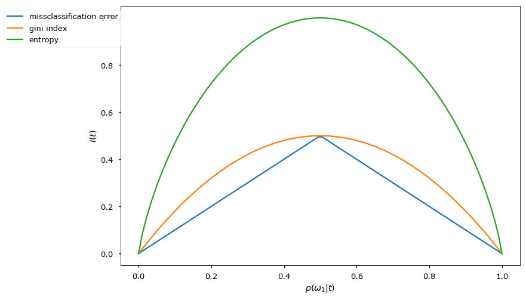

```python
plot_impurities()
```

## Splitting criterion selection

- Define $\Delta I(t)$ - is the quality of the split of node $t$ into child nodes $t_{1},...t_{C}$. $$ \Delta I(t)=I(t)-\sum_{i=1}^{C}I(t_{i})\frac{N(t_{i})}{N(t)} $$ $$ \Delta I(t)=I(t)-\left(I(t_{L})\frac{N(t_{L})}{N(t)} + I(t_{R})\frac{N(t_{R})}{N(t)}\right) $$
  - If $I(t)$ is entropy, then $\Delta I(t)$ is called *information gain*.
- CART optimization (regression, classification): select feature $i_{t}$ and threshold $h_{t}$, which maximize $\Delta I(t)$: $$ i_{t},\,h_{t}=\arg\max_{k,h}\Delta I(t) $$
- CART decision making: from node $t$ follow:

$$\begin{cases} \text{left child }t_{1}, & \text{if }x^{i_{t}}\le h_{t}\\ \text{right child }t_{2}, & \text{if }x^{i_{t}}>h_{t} \end{cases}$$

## Splitting criterion selection

**Remarks**

- Local and Greedy optimization
- Overall results changes slighly with different impurity measures

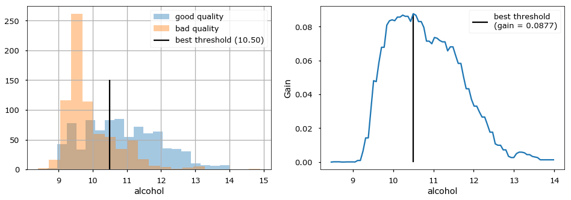

```python
wine_demo()
```

## Typical regression impurity functions

- Impurity function measures uncertainty in $y$ for objects falling inside node $t$.
  - Regression:
    - let objects falling inside node $t$ be $I=\{i_{1},...i_{K}\}$. We may define \begin{align*} \phi(t) & =\frac{1}{K}\sum_{i\in I}\left(y_{i}-\mu\right)^{2}\quad \text{(MSE)}\\ \phi(t) & =\frac{1}{K}\sum_{i\in I}|y_{i}-\mu|\quad \text{(MAE)} \end{align*} where $\mu$ is `mean` or `median` of $y_i$s.

## Prediction assignment to leaves

- Regression:
  - mean (optimal for MSE loss)
  - median (optimal for MAE loss)
- Classification
  - most common class (optimal for constant misclassification cost)

## Classification example

```python
fig = interact(demo_dec_tree, depth=IntSlider(min=1, max=5, value=1))
```

[output not shown]

## Regression example

```python
fig = interact(plot_dec_reg, depth=IntSlider(min=1, max=5, value=1), criterion=['mse', 'mae'])
```

[output not shown]

# Termination criterion

## Termination criterion

- Tradeoff:
  - very large complex trees -> overfitting
  - very short simple trees -> underfitting
- Approaches to stopping:
  - rule-based
  - based on pruning (not considered here)

## Rule-base termination criteria

- Rule-based: a criterion is compared with a threshold.
- Variants of criterion:
  - depth of tree
  - number of objects in a node
  - minimal number of objects in one of the child nodes
  - impurity of classes
  - change of impurity of classes after the split
  - etc

## Analysis of rule-based termination

Advantages:

- simplicity
- interpretability

Disadvantages:

- specification of threshold is needed

# Other features

## Tree feature importances

- Consider feature $f$
- Let $T(f)$ be the set of all nodes, relying on feature $f$ when making split.
  - efficiency of split at node $t$: $\Delta I(t)=I(t)-\sum_{c\in childen(t)}\frac{n_{c}}{n_{t}}I(c)$
  - feature importance of $f$: $\sum_{t\in T(f)}n_{t}\Delta I(t)$
- Alternative: difference in decision tree prediction quality for
  - original validation set
  - validation set with $j$-th feature randomly shuffled

## Handling missing values

1. Remove features or objects with missing values
2. Missing value = distinct feature value
3. Calculation of impurity w/o missing cases
4. **Surrogate split!**
   - Find best split with feature $i^*$, threshold $h^*$ and children $\{t^*_L, t^*_R\}$
   - Find other good splits for features $i_t \neq i^*$, s.t. $\{t_L, t_R\} \approx \{t^*_L, t^*_R\}$
   - While performing prediction of object $x$:
     - If $x^{i^*}$ is `Null`, try $x^{i_t}$

## Analysis of decision trees

- **Advantages:**
  - simplicity of algorithm
  - interpretability of model (for short trees)
  - implicit feature selection
  - good for features of different nature:
    - naturally handles both discrete and real features
    - prediction is invariant to monotone transformations of features

## Analysis of decision trees

- **Disadvantages:**
  - not very high accuracy:
    - high overfitting of tree structure up to top
    - non-parallel to axes class separating boundary may lead to many nodes in the tree for $Q_{t}(x)=x^{i(t)}$
    - one step ahead lookup strategy for split selection may be insufficient (XOR example)
  - not online - slight modification of the training set will require full tree reconstruction.

## Special Desicion Tree Algorithms

**ID 3**

- Categorical features only
- Number of children = number of categories
- Maximum depth

**С 4.5**

- Handling continious features
- And categorical as in ID3
- Find missing value - proceed down to all paths and average
- Some prunning procedure

## Interpretation of DT

[figure not shown]

- http://blog.datadive.net/interpreting-random-forests/
- https://eli5.readthedocs.io/en/latest/

## FYI

- [How tree works](http://www.r2d3.us/visual-intro-to-machine-learning-part-1/)